# Final 250a project!

Yael Reuben Ben

May 27, 2016

Connecting Rstudio to out H20 cluster

```r
library(h2o)
library(dplyr)
```

```r
library(ggplot2)
library(tidyr)

cluster <- h2o.init(ip="52.53.176.50", strict_version_check = FALSE)
```

```
##  Connection successful!
##
## R is connected to the H2O cluster:
##     H2O cluster uptime:         1 hours 17 minutes
##     H2O cluster version:        3.8.2.2
##     H2O cluster name:           H2ODemo
##     H2O cluster total nodes:    4
##     H2O cluster total memory:   86.68 GB
##     H2O cluster total cores:    32
##     H2O cluster allowed cores:  32
##     H2O cluster healthy:        TRUE
##     H2O Connection ip:          52.53.176.50
##     H2O Connection port:        54321
##     H2O Connection proxy:       NA
##     R Version:                  R version 3.2.3 (2015-12-10)
```

```r
h2o.clusterStatus()
```

```
## Version: 3.8.2.2
## Cloud name: H2ODemo
## Cloud size: 4
## Cloud is locked
```

```
##                   h2o healthy    last_ping num_cpus sys_load
## 1 /172.31.25.29:54321    TRUE 1.464579e+12        8        0
## 2 /172.31.25.30:54321    TRUE 1.464579e+12        8        0
## 3 /172.31.25.31:54321    TRUE 1.464579e+12        8        0
## 4 /172.31.25.32:54321    TRUE 1.464579e+12        8        0
##   mem_value_size    free_mem pojo_mem swap_mem   free_disk    max_disk
## 1     4599992320 22338971648 54001664        0 21045968896 29456596992
## 2     3557636096 23373724672 61605888        0 21045968896 29456596992
## 3     3366463488 23542759424 83742720        0 21043871744 29456596992
## 4     3100889088 23820904448 71172096        0 21045968896 29456596992
##    pid num_keys tcps_active open_fds rpcs_active
## 1 3022     8508           6       45           0
## 2 3020     6946           6       43           0
## 3 3021     6238           6       60           0
## 4 3021     5721           5       43           0
```

Read data frame - that we loaded to Flow

```
##  Station          WBAN             Year           MonthDay
##  Min.   :  7018   99999:116684384  Min.   :1929   Min.   : 101.0
##  1st Qu.:255264   24131:    28723  1st Qu.:1980   1st Qu.: 330.6
##  Median :561102   24155:    28618  Median :1994   Median : 700.4
##  Mean   :516194   23119:    28582  Mean   :1992   Mean   : 665.8
##  3rd Qu.:724944   13743:    28459  3rd Qu.:2007   3rd Qu.:1000.1
##  Max.   :999999   22521:    28102  Max.   :2016   Max.   :1231.0
##
##  temp              temp cnt        dewpoint           dewpoint cnt
##  Min.   :-118.50   Min.   : 4.00   Min.   : -126.60   Min.   : 0.00
##  1st Qu.:  38.48   1st Qu.: 7.00   1st Qu.:   25.30   1st Qu.: 6.00
##  Median :  55.39   Median : 8.00   Median :   35.42   Median : 8.00
##  Mean   :  52.54   Mean   :13.79   Mean   :  532.59   Mean   :12.95
##  3rd Qu.:  70.70   3rd Qu.:24.00   3rd Qu.:   55.68   3rd Qu.:24.00
##  Max.   : 110.00   Max.   :24.00   Max.   : 9999.90   Max.   :24.00
##
##  sea level pres  sea cnt          station pres      stat cnt
##  Min.   :  900   Min.   : 0.000   Min.   :  545.0   Min.   :0.000
##  1st Qu.: 1009   1st Qu.: 0.000   1st Qu.:  998.8   1st Qu.:0.000
##  Median : 1018   Median : 7.000   Median : 9990.4   Median :0.000
##  Mean   : 3413   Mean   : 8.641   Mean   : 6064.8   Mean   :2.363
##  3rd Qu.: 9991   3rd Qu.:10.000   3rd Qu.: 9990.4   3rd Qu.:4.000
##  Max.   :10000   Max.   :24.000   Max.   : 9999.9   Max.   :9.000
##
##  visibility        visi cnt        mean wind speed   wind speed cnt
##  Min.   :  0.000   Min.   : 0.00   Min.   :  0.000   Min.   : 0.00
##  1st Qu.:  5.999   1st Qu.: 5.00   1st Qu.:  3.000   1st Qu.: 7.00
##  Median :  9.999   Median : 8.00   Median :  5.000   Median : 8.00
##  Mean   :140.941   Mean   :11.43   Mean   : 25.313   Mean   :13.42
##  3rd Qu.: 18.998   3rd Qu.:23.00   3rd Qu.:  8.999   3rd Qu.:24.00
##  Max.   :999.900   Max.   :24.00   Max.   :999.900   Max.   :24.00
##
##  max wind speed    gust speed      max temp           *is hourly max
##  Min.   :  0.200   Min.   :  1.0   Min.   : -117.40   Min.   : Inf
##  1st Qu.:  7.198   1st Qu.:998.9   1st Qu.:   44.48   1st Qu.: NaN
##  Median : 11.197   Median :998.9   Median :   64.71   Median : NaN
##  Mean   : 46.846   Mean   :845.8   Mean   :   74.30   Mean   :   0
##  3rd Qu.: 15.195   3rd Qu.:998.9   3rd Qu.:   74.83   3rd Qu.: NaN
##  Max.   :999.900   Max.   :999.9   Max.   : 9999.90   Max.   :-Inf
##                                                       NA's   :139410254
```

[output cut: 9 more lines]

```
##  Min.   :  0.4   Min.   :0.0000   Min.   :0.000   Min.   :0.00000
##  1st Qu.:998.9   1st Qu.:0.0000   1st Qu.:0.000   1st Qu.:0.00000
##  Median :998.9   Median :0.0000   Median :0.000   Median :0.00000
##  Mean   :944.5   Mean   :0.0961   Mean   :0.256   Mean   :0.09078
##  3rd Qu.:998.9   3rd Qu.:0.0000   3rd Qu.:1.000   3rd Qu.:0.00000
##  Max.   :999.9   Max.   :1.0000   Max.   :1.000   Max.   :1.00000
##
##  hail               thunder           tornado
##  Min.   :0.000000   Min.   :0.00000   Min.   :0.0000000
##  1st Qu.:0.000000   1st Qu.:0.00000   1st Qu.:0.0000000
##  Median :0.000000   Median :0.00000   Median :0.0000000
##  Mean   :0.002944   Mean   :0.05017   Mean   :0.0001817
##  3rd Qu.:0.000000   3rd Qu.:0.00000   3rd Qu.:0.0000000
##  Max.   :1.000000   Max.   :1.00000   Max.   :1.0000000
##
```

Looking at global wearming

## Average temp increases over the years

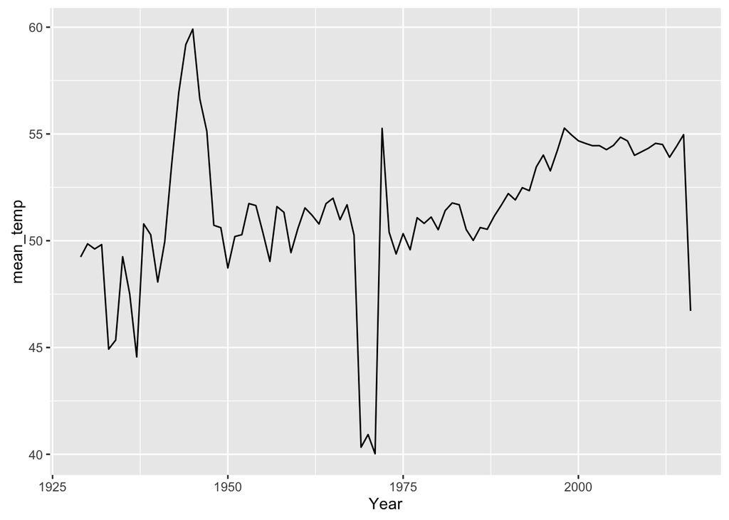

```r
## Plotting avg
temp_by_year <- h2o.group_by(orig, by="Year",
                           nrow("temp"), sum("temp"), mean("temp"), sd("temp"))
# summary(temp_by_year)
# head(temp_by_year)

df <- as.data.frame(temp_by_year)
df %>%
  ggplot() +
    geom_line(mapping = aes(x = Year, y = mean_temp))
```

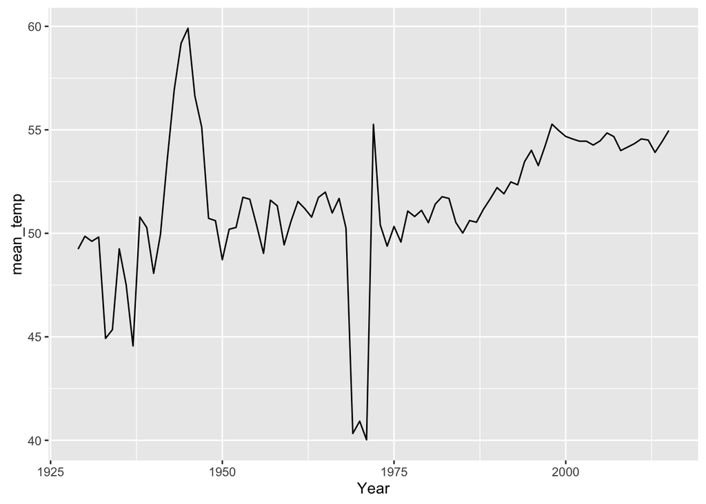

```r
# incomplete data for 2016
df %>%
  filter(Year != 2016) %>%
  ggplot() +
    geom_line(mapping = aes(x = Year, y = mean_temp))
```

## First attempt at adding weather data

```r
# stations <- h2o.getFrame("emshr_lite.hex")
# h2o.summary(stations)
# head(stations)
# orig$WBAN <- as.factor(orig$WBAN)
#
# j <- h2o.merge(orig, stations)
# j_allx <- h2o.merge(orig, stations, all.x = TRUE)
#
# nrow(orig)
# nrow(j)
# nrow(j_allx)
#
# h2o.summary(j_allx)
```

## Joing with weather data

In the first try we saw the data set wasn’t parsing correctly.

We found another data set and tried again:

```r
# try again new data. forst one has a parsing problem becuase of fixed width
stations2 <- h2o.getFrame("Key_Frame__weather_stations.hex")
j2 <- h2o.merge(orig, stations2)
nrow(j2)
```

```
## [1] 6938005
```

```r
names(j2)
```

```
##  [1] "Station"          "WBAN"             "Year"
##  [4] "MonthDay"         "temp"             "temp cnt"
##  [7] "dewpoint"         "dewpoint cnt"     "sea level pres"
## [10] "sea cnt"          "station pres"     "stat cnt"
## [13] "visibility"       "visi cnt"         "mean wind speed"
## [16] "wind speed cnt"   "max wind speed"   "gust speed"
## [19] "max temp"         "*is hourly max"   "min temp"
## [22] "*is hourly min"   "precipitation"    "precip report"
## [25] "snow depth"       "fog"              "rain"
## [28] "snow"             "hail"             "thunder"
## [31] "tornado"          "station_name"     "stateprov"
## [34] "climate_division" "country_name"     "ncdc_station_id"
## [37] "latitude"         "longitude"        "elevation"
## [40] "end_date"
```

```r
h2o.unique(j2$stateprov)
```

```
##   C1
## 1 AK
## 2 AL
## 3 AR
## 4 AS
## 5 AZ
## 6 CA
##
## [61 rows x 1 column]
```

```r
# Looks better!
```

## Plotting global wearming in specific location

Alaska colder than Texas: trends per-station

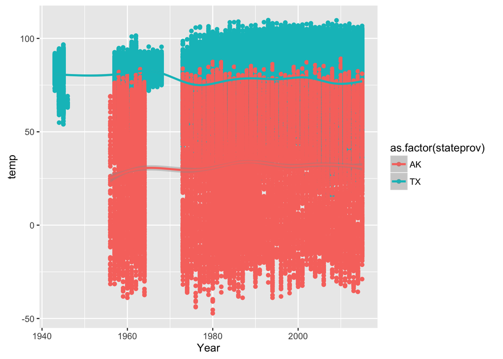

```r
j2.TX_AK <- j2[j2$stateprov == "TX" | j2$stateprov == "AK",]
# head(j2.TX_AK)
# h2o.summary(j2.TX_AK)

j2.TX_AK.df <- as.data.frame(j2.TX_AK)

j2.TX_AK.df %>%
  filter(Station != 999999, Year != 2016) %>%
  ggplot(mapping = aes(x = Year, y = temp, color = as.factor(stateprov))) +
    geom_point() +
    geom_smooth()
```

## Winter colder than summer: trends per-day-of-year

```r
names(orig)
```

```
##  [1] "Station"         "WBAN"            "Year"
##  [4] "MonthDay"        "temp"            "temp cnt"
##  [7] "dewpoint"        "dewpoint cnt"    "sea level pres"
## [10] "sea cnt"         "station pres"    "stat cnt"
## [13] "visibility"      "visi cnt"        "mean wind speed"
## [16] "wind speed cnt"  "max wind speed"  "gust speed"
## [19] "max temp"        "*is hourly max"  "min temp"
## [22] "*is hourly min"  "precipitation"   "precip report"
## [25] "snow depth"      "fog"             "rain"
## [28] "snow"            "hail"            "thunder"
## [31] "tornado"
```

```r
summary(orig)
```

```
##  Station          WBAN             Year           MonthDay
##  Min.   :  7018   99999:116684384  Min.   :1929   Min.   : 101.0
##  1st Qu.:255264   24131:    28723  1st Qu.:1980   1st Qu.: 330.6
##  Median :561102   24155:    28618  Median :1994   Median : 700.4
##  Mean   :516194   23119:    28582  Mean   :1992   Mean   : 665.8
##  3rd Qu.:724944   13743:    28459  3rd Qu.:2007   3rd Qu.:1000.1
##  Max.   :999999   22521:    28102  Max.   :2016   Max.   :1231.0
##
##  temp              temp cnt        dewpoint           dewpoint cnt
##  Min.   :-118.50   Min.   : 4.00   Min.   : -126.60   Min.   : 0.00
##  1st Qu.:  38.48   1st Qu.: 7.00   1st Qu.:   25.30   1st Qu.: 6.00
##  Median :  55.39   Median : 8.00   Median :   35.42   Median : 8.00
##  Mean   :  52.54   Mean   :13.79   Mean   :  532.59   Mean   :12.95
##  3rd Qu.:  70.70   3rd Qu.:24.00   3rd Qu.:   55.68   3rd Qu.:24.00
##  Max.   : 110.00   Max.   :24.00   Max.   : 9999.90   Max.   :24.00
##
##  sea level pres  sea cnt          station pres      stat cnt
##  Min.   :  900   Min.   : 0.000   Min.   :  545.0   Min.   :0.000
##  1st Qu.: 1009   1st Qu.: 0.000   1st Qu.:  998.8   1st Qu.:0.000
##  Median : 1018   Median : 7.000   Median : 9990.4   Median :0.000
##  Mean   : 3413   Mean   : 8.641   Mean   : 6064.8   Mean   :2.363
##  3rd Qu.: 9991   3rd Qu.:10.000   3rd Qu.: 9990.4   3rd Qu.:4.000
##  Max.   :10000   Max.   :24.000   Max.   : 9999.9   Max.   :9.000
##
##  visibility        visi cnt        mean wind speed   wind speed cnt
##  Min.   :  0.000   Min.   : 0.00   Min.   :  0.000   Min.   : 0.00
##  1st Qu.:  5.999   1st Qu.: 5.00   1st Qu.:  3.000   1st Qu.: 7.00
##  Median :  9.999   Median : 8.00   Median :  5.000   Median : 8.00
##  Mean   :140.941   Mean   :11.43   Mean   : 25.313   Mean   :13.42
##  3rd Qu.: 18.998   3rd Qu.:23.00   3rd Qu.:  8.999   3rd Qu.:24.00
##  Max.   :999.900   Max.   :24.00   Max.   :999.900   Max.   :24.00
##
##  max wind speed    gust speed      max temp           *is hourly max
##  Min.   :  0.200   Min.   :  1.0   Min.   : -117.40   Min.   : Inf
##  1st Qu.:  7.198   1st Qu.:998.9   1st Qu.:   44.48   1st Qu.: NaN
##  Median : 11.197   Median :998.9   Median :   64.71   Median : NaN
##  Mean   : 46.846   Mean   :845.8   Mean   :   74.30   Mean   :   0
##  3rd Qu.: 15.195   3rd Qu.:998.9   3rd Qu.:   74.83   3rd Qu.: NaN
##  Max.   :999.900   Max.   :999.9   Max.   : 9999.90   Max.   :-Inf
##                                                       NA's   :139410254
```

[output cut: 9 more lines]

```
##  Min.   :  0.4   Min.   :0.0000   Min.   :0.000   Min.   :0.00000
##  1st Qu.:998.9   1st Qu.:0.0000   1st Qu.:0.000   1st Qu.:0.00000
##  Median :998.9   Median :0.0000   Median :0.000   Median :0.00000
##  Mean   :944.5   Mean   :0.0961   Mean   :0.256   Mean   :0.09078
##  3rd Qu.:998.9   3rd Qu.:0.0000   3rd Qu.:1.000   3rd Qu.:0.00000
##  Max.   :999.9   Max.   :1.0000   Max.   :1.000   Max.   :1.00000
##
##  hail               thunder           tornado
##  Min.   :0.000000   Min.   :0.00000   Min.   :0.0000000
##  1st Qu.:0.000000   1st Qu.:0.00000   1st Qu.:0.0000000
##  Median :0.000000   Median :0.00000   Median :0.0000000
##  Mean   :0.002944   Mean   :0.05017   Mean   :0.0001817
##  3rd Qu.:0.000000   3rd Qu.:0.00000   3rd Qu.:0.0000000
##  Max.   :1.000000   Max.   :1.00000   Max.   :1.0000000
##
```

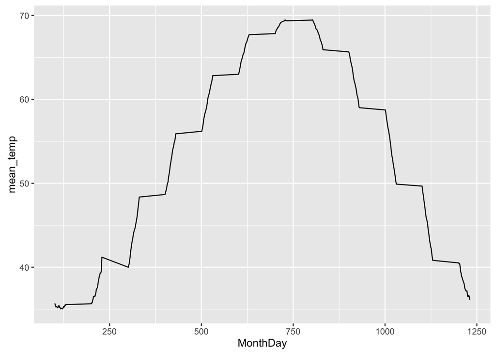

```r
temp_by_md <- h2o.group_by(orig, by="MonthDay",
                           nrow("temp"), sum("temp"), mean("temp"), sd("temp"))
temp_by_md.df <- as.data.frame(temp_by_md)

temp_by_md.df  %>%
  ggplot() +
    geom_line(mapping = aes(x = MonthDay, y = mean_temp))
```

```r
###
```

Some funkiness going on here, but including ‘MonthDay’ together won’t make a difference in our prediction task later on.

## Find increases in weather extremes

Increases in tornadoes

```r
h2o.summary(orig)
```

```
##  Station          WBAN             Year           MonthDay
##  Min.   :  7018   99999:116684384  Min.   :1929   Min.   : 101.0
##  1st Qu.:255264   24131:    28723  1st Qu.:1980   1st Qu.: 330.6
##  Median :561102   24155:    28618  Median :1994   Median : 700.4
##  Mean   :516194   23119:    28582  Mean   :1992   Mean   : 665.8
##  3rd Qu.:724944   13743:    28459  3rd Qu.:2007   3rd Qu.:1000.1
##  Max.   :999999   22521:    28102  Max.   :2016   Max.   :1231.0
##
##  temp              temp cnt        dewpoint           dewpoint cnt
##  Min.   :-118.50   Min.   : 4.00   Min.   : -126.60   Min.   : 0.00
##  1st Qu.:  38.48   1st Qu.: 7.00   1st Qu.:   25.30   1st Qu.: 6.00
##  Median :  55.39   Median : 8.00   Median :   35.42   Median : 8.00
##  Mean   :  52.54   Mean   :13.79   Mean   :  532.59   Mean   :12.95
##  3rd Qu.:  70.70   3rd Qu.:24.00   3rd Qu.:   55.68   3rd Qu.:24.00
##  Max.   : 110.00   Max.   :24.00   Max.   : 9999.90   Max.   :24.00
##
##  sea level pres  sea cnt          station pres      stat cnt
##  Min.   :  900   Min.   : 0.000   Min.   :  545.0   Min.   :0.000
##  1st Qu.: 1009   1st Qu.: 0.000   1st Qu.:  998.8   1st Qu.:0.000
##  Median : 1018   Median : 7.000   Median : 9990.4   Median :0.000
##  Mean   : 3413   Mean   : 8.641   Mean   : 6064.8   Mean   :2.363
##  3rd Qu.: 9991   3rd Qu.:10.000   3rd Qu.: 9990.4   3rd Qu.:4.000
##  Max.   :10000   Max.   :24.000   Max.   : 9999.9   Max.   :9.000
##
##  visibility        visi cnt        mean wind speed   wind speed cnt
##  Min.   :  0.000   Min.   : 0.00   Min.   :  0.000   Min.   : 0.00
##  1st Qu.:  5.999   1st Qu.: 5.00   1st Qu.:  3.000   1st Qu.: 7.00
##  Median :  9.999   Median : 8.00   Median :  5.000   Median : 8.00
##  Mean   :140.941   Mean   :11.43   Mean   : 25.313   Mean   :13.42
##  3rd Qu.: 18.998   3rd Qu.:23.00   3rd Qu.:  8.999   3rd Qu.:24.00
##  Max.   :999.900   Max.   :24.00   Max.   :999.900   Max.   :24.00
##
##  max wind speed    gust speed      max temp           *is hourly max
##  Min.   :  0.200   Min.   :  1.0   Min.   : -117.40   Min.   : Inf
##  1st Qu.:  7.198   1st Qu.:998.9   1st Qu.:   44.48   1st Qu.: NaN
##  Median : 11.197   Median :998.9   Median :   64.71   Median : NaN
##  Mean   : 46.846   Mean   :845.8   Mean   :   74.30   Mean   :   0
##  3rd Qu.: 15.195   3rd Qu.:998.9   3rd Qu.:   74.83   3rd Qu.: NaN
##  Max.   :999.900   Max.   :999.9   Max.   : 9999.90   Max.   :-Inf
##                                                       NA's   :139410254
```

[output cut: 9 more lines]

```
##  Min.   :  0.4   Min.   :0.0000   Min.   :0.000   Min.   :0.00000
##  1st Qu.:998.9   1st Qu.:0.0000   1st Qu.:0.000   1st Qu.:0.00000
##  Median :998.9   Median :0.0000   Median :0.000   Median :0.00000
##  Mean   :944.5   Mean   :0.0961   Mean   :0.256   Mean   :0.09078
##  3rd Qu.:998.9   3rd Qu.:0.0000   3rd Qu.:1.000   3rd Qu.:0.00000
##  Max.   :999.9   Max.   :1.0000   Max.   :1.000   Max.   :1.00000
##
##  hail               thunder           tornado
##  Min.   :0.000000   Min.   :0.00000   Min.   :0.0000000
##  1st Qu.:0.000000   1st Qu.:0.00000   1st Qu.:0.0000000
##  Median :0.000000   Median :0.00000   Median :0.0000000
##  Mean   :0.002944   Mean   :0.05017   Mean   :0.0001817
##  3rd Qu.:0.000000   3rd Qu.:0.00000   3rd Qu.:0.0000000
##  Max.   :1.000000   Max.   :1.00000   Max.   :1.0000000
##
```

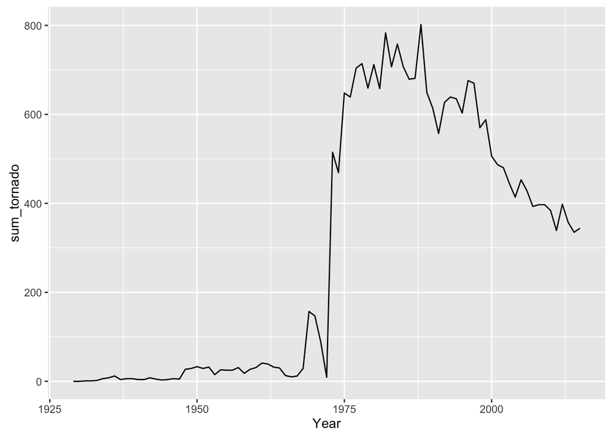

```r
tornado_by_year <- h2o.group_by(orig, by="Year",
                           nrow("tornado"), sum("tornado"),
                           mean("tornado"), sd("tornado"))

tornado_by_year.df <- as.data.frame(tornado_by_year)

tornado_by_year.df %>%
  filter(Year != 2016) %>%
  ggplot() +
    geom_line(mapping = aes(x = Year, y = sum_tornado))
```

## Increases in std-dev of min & max temps

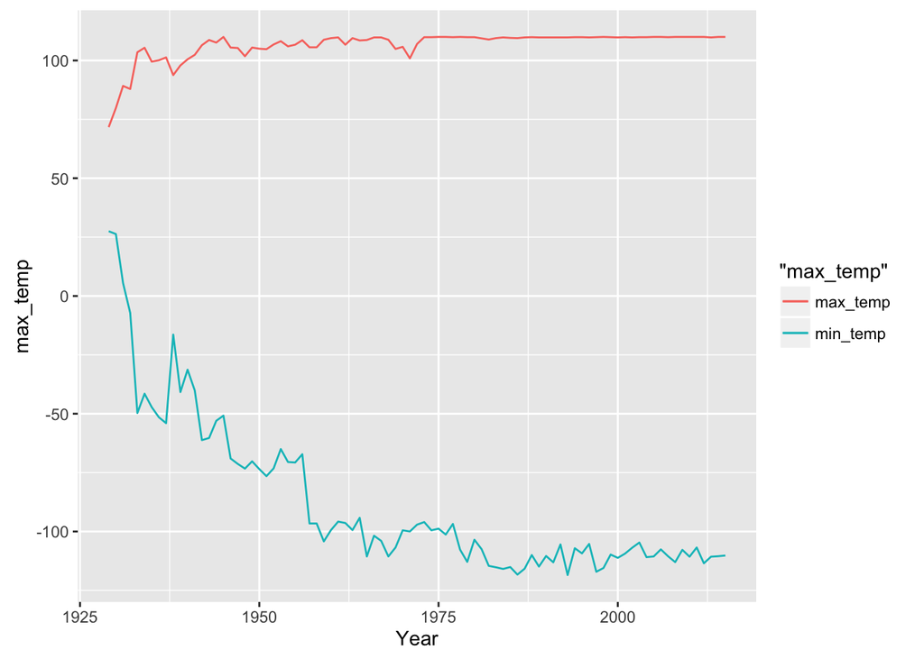

```r
temp_by_year <- h2o.group_by(orig, by="Year",
                           max("temp"), min("temp"),
                           mean("temp"), sd("temp"))

temp_by_year.df <- as.data.frame(temp_by_year)

# temp
temp_by_year.df %>%
  filter(Year != 2016) %>%
  ggplot() +
    geom_line(mapping = aes(x = Year, y = max_temp, color = "max_temp")) +
    geom_line(mapping = aes(x = Year, y = min_temp, color = "min_temp"))
```

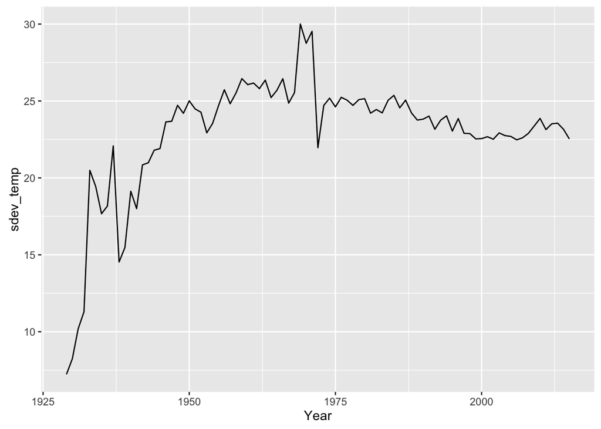

```r
#sd temp
temp_by_year.df %>%
  filter(Year != 2016) %>%
  ggplot() +
    geom_line(mapping = aes(x = Year, y = sdev_temp))
```

# Model runs

step1 - created basic model in flow a. split data 25 - 75 b. pick cols

```r
h2o.getModel("glm-da2b9e9f-1d54-4459-8521-fb5119f3f434")
```

```
## Model Details:
## ==============
##
## H2ORegressionModel: glm
## Model ID:  glm-da2b9e9f-1d54-4459-8521-fb5119f3f434
## GLM Model: summary
##     family     link                               regularization
## 1 gaussian identity Elastic Net (alpha = 0.5, lambda = 0.02047 )
##   number_of_predictors_total number_of_active_predictors
## 1                         17                          16
##   number_of_iterations training_frame
## 1                    0    frame_0.750
##
## Coefficients: glm coefficients
##            names coefficients standardized_coefficients
## 1      Intercept  -218.599968                 52.547381
## 2        Station     0.000018                  5.567649
## 3           WBAN     0.000035                  0.958927
## 4           Year     0.115626                  2.049649
## 5       MonthDay     0.005347                  1.849339
## 6       dewpoint    -0.000457                 -0.985007
## 7        sea cnt    -0.029407                 -0.246263
## 8     visibility    -0.008595                 -2.862580
## 9     gust speed     0.004118                  1.465117
## 10 precipitation    -0.025406                 -0.718592
## 11    snow depth     0.025634                  5.831806
## 12           fog    -3.481011                 -1.025951
## 13          rain     3.855342                  1.682493
## 14          snow   -25.394995                 -7.295367
## 15          hail    -0.008395                 -0.000455
## 16       thunder    11.701679                  2.554446
## 17       tornado     5.930961                  0.079931
##
## H2ORegressionMetrics: glm
## ** Reported on training data. **
##
## MSE:  385.0629
## R2 :  0.3338619
## Mean Residual Deviance :  385.0629
## Null Deviance :60439794889
## Null D.o.F. :104557594
## Residual Deviance :40261252956
## Residual D.o.F. :104557578
## AIC :919195529
##
##
## H2ORegressionMetrics: glm
## ** Reported on validation data. **
##
## MSE:  385.3679
## R2 :  0.3337794
## Mean Residual Deviance :  385.3679
## Null Deviance :20160134664
## Null D.o.F. :34852658
## Residual Deviance :13431095355
## Residual D.o.F. :34852642
## AIC :306427245
```

Now we are going to try only station and date in order to see if we can predict using this

```r
h2o.getModel("glm-0a2dfcb7-f79b-4c62-8db1-d5b8b4d31ffb")
```

```
## Model Details:
## ==============
##
## H2ORegressionModel: glm
## Model ID:  glm-0a2dfcb7-f79b-4c62-8db1-d5b8b4d31ffb
## GLM Model: summary
##     family     link                               regularization
## 1 gaussian identity Elastic Net (alpha = 0.5, lambda = 0.01205 )
##   number_of_predictors_total number_of_active_predictors
## 1                          5                           4
##   number_of_iterations training_frame
## 1                    0    frame_0.750
##
## Coefficients: glm coefficients
##       names coefficients standardized_coefficients
## 1 Intercept  -117.656351                 52.547381
## 2   Station     0.000021                  6.358610
## 3      WBAN     0.000041                  1.146155
## 4      Year     0.075267                  1.334227
## 5  MonthDay     0.008619                  2.981093
##
## H2ORegressionMetrics: glm
## ** Reported on training data. **
##
## MSE:  529.4799
## R2 :  0.0840282
## Mean Residual Deviance :  529.4799
## Null Deviance :60439794889
## Null D.o.F. :104557594
## Residual Deviance :55361147698
## Residual D.o.F. :104557590
## AIC :952495897
##
##
## H2ORegressionMetrics: glm
## ** Reported on validation data. **
##
## MSE:  529.9047
## R2 :  0.08390542
## Mean Residual Deviance :  529.9047
## Null Deviance :20160134664
## Null D.o.F. :34852658
## Residual Deviance :18468586541
## Residual D.o.F. :34852654
## AIC :317527747
```

It works very poorly - r2 = 0.08

We noticed that it reads station and WBAN as numeric. we converted to enum and ran again:

```r
h2o.getModel("glm-f1e8f8e6-3dee-4626-ac7c-0b074df6a606")
```

```
## Model Details:
## ==============
##
## H2ORegressionModel: glm
## Model ID:  glm-f1e8f8e6-3dee-4626-ac7c-0b074df6a606
## GLM Model: summary
##     family     link                                regularization
## 1 gaussian identity Elastic Net (alpha = 0.5, lambda = 0.006011 )
##   number_of_predictors_total number_of_active_predictors
## 1                      25389                         618
##   number_of_iterations training_frame
## 1                    0    frame_0.750
##
## Coefficients: glm coefficients
##          names coefficients standardized_coefficients
## 1    Intercept  -134.574134                 54.758883
## 2 Station.7018     0.000000                  0.000000
## 3 Station.7026     0.000000                  0.000000
## 4 Station.7034     0.000000                  0.000000
## 5 Station.7037     0.000000                  0.000000
##
## ---
##                  names coefficients standardized_coefficients
## 25384       WBAN.96407     0.000000                  0.000000
## 25385       WBAN.96408     0.000000                  0.000000
## 25386       WBAN.99999    -2.660717                 -2.660717
## 25387 WBAN.missing(NA)     0.000000                  0.000000
## 25388             Year     0.092144                  1.633394
## 25389         MonthDay     0.008732                  3.020264
##
## H2ORegressionMetrics: glm
## ** Reported on training data. **
##
## MSE:  563.603
## R2 :  0.02499704
## Mean Residual Deviance :  563.603
## Null Deviance :60439794889
## Null D.o.F. :104557594
## Residual Deviance :58928978924
## Residual D.o.F. :104556976
## AIC :959027262
##
##
## H2ORegressionMetrics: glm
## ** Reported on validation data. **
##
## MSE:  563.9962
## R2 :  0.02496831
## Mean Residual Deviance :  563.9962
## Null Deviance :20160134664
## Null D.o.F. :34852658
## Residual Deviance :19656766287
## Residual D.o.F. :34852040
## AIC :319702051
```

got worse - r2 = 0.02

In order to improve the baseline model we are trying to introduce more features:

Using location data from the station df

```r
# j2.split <- h2o.splitFrame(j2)
# j2.split.75 <- j2.split[[1]]
# j2.split.25 <- j2.split[[2]]
#

j2.glm_3 <- h2o.glm(x = c("Station", "elevation", "MonthDay",
                        "Year", "climate_division"), y = "temp",
                  training_frame = j2, nfolds = 3, family = "gaussian")
j2.glm_3@model$cross_validation_metrics
```

```
## H2ORegressionMetrics: glm
## ** Reported on cross-validation data. **
## Description: 3-fold cross-validation on training data (Metrics computed for combined holdout predictions)
##
## MSE:  551.6244
## R2 :  0.1143856
## Mean Residual Deviance :  551.6244
## Null Deviance :4321489260
## Null D.o.F. :6938004
## Residual Deviance :3827172617
## Residual D.o.F. :6937999
## AIC :63487924
```

R2 = 0.11 Boo

Lets add at lng information from out enriched data set

```r
j2.glm_3_lat <- h2o.glm(x = c("Station", "elevation", "latitude", "longitude",
                              "MonthDay","Year", "climate_division"), y = "temp",
                  training_frame = j2, nfolds = 3, family = "gaussian")
j2.glm_3_lat@model$cross_validation_metrics
```

```
## H2ORegressionMetrics: glm
## ** Reported on cross-validation data. **
## Description: 3-fold cross-validation on training data (Metrics computed for combined holdout predictions)
##
## MSE:  440.2568
## R2 :  0.2931825
## Mean Residual Deviance :  440.2568
## Null Deviance :4321489831
## Null D.o.F. :6938004
## Residual Deviance :3054503730
## Residual D.o.F. :6937114
## AIC :61925111
```

```r
summary(j2.glm_3)
```

```
## Model Details:
## ==============
##
## H2ORegressionModel: glm
## Model Key:  GLM_model_R_1464574377491_11
## GLM Model: summary
##     family     link                               regularization
## 1 gaussian identity Elastic Net (alpha = 0.5, lambda = 0.01323 )
##   number_of_predictors_total number_of_active_predictors
## 1                          6                           5
##   number_of_iterations  training_frame
## 1                    0 RTMP_sid_a65f_2
##
## H2ORegressionMetrics: glm
## ** Reported on training data. **
##
## MSE:  551.6238
## R2 :  0.1143865
## Mean Residual Deviance :  551.6238
## Null Deviance :4321488752
## Null D.o.F. :6938004
## Residual Deviance :3827168593
## Residual D.o.F. :6937999
## AIC :63487917
##
##
##
## Scoring History:
## data frame with 0 columns and 0 rows
##
## Variable Importances: (Extract with `h2o.varimp`)
## =================================================
##
## Standardized Coefficient Magnitudes: standardized coefficient magnitudes
##              names coefficients sign
## 1          Station     6.875539  POS
## 2         MonthDay     3.550701  POS
## 3             Year     3.208989  POS
## 4        elevation     1.742527  NEG
## 5 climate_division     1.405508  POS
```

It got better! R2 = 0.29.

The lat long matter! wohoo

Now how about a different algorithm

```r
j2.rf <- h2o.randomForest(x = c("Station", "elevation", "latitude", "longitude",
                              "MonthDay","Year", "climate_division"), y = "temp",
                  max_depth = 5, ntrees = 10, training_frame = j2, nfolds = 3)
j2.rf@model$cross_validation_metrics
```

```
## H2ORegressionMetrics: drf
## ** Reported on cross-validation data. **
## Description: 3-fold cross-validation on training data (Metrics computed for combined holdout predictions)
##
## MSE:  244.987
## R2 :  0.6066816
## Mean Residual Deviance :  244.987
```

```r
summary(j2.rf)
```

```
## Model Details:
## ==============
##
## H2ORegressionModel: drf
## Model Key:  DRF_model_R_1464574377491_13
## Model Summary:
##   number_of_trees model_size_in_bytes min_depth max_depth mean_depth
## 1              10                4619         5         5    5.00000
##   min_leaves max_leaves mean_leaves
## 1         29         32    31.60000
##
## H2ORegressionMetrics: drf
## ** Reported on training data. **
## Description: Metrics reported on Out-Of-Bag training samples
##
## MSE:  265.8882
## R2 :  0.5731219
## Mean Residual Deviance :  265.8882
##
##
##
## Scoring History:
##             timestamp   duration number_of_trees training_MSE
## 1 2016-05-30 03:32:04 20.441 sec               0
## 2 2016-05-30 03:32:05 21.717 sec               1    245.27070
## 3 2016-05-30 03:32:06 22.676 sec               2    298.63824
## 4 2016-05-30 03:32:07 23.411 sec               3    280.37733
## 5 2016-05-30 03:32:08 24.151 sec               4    281.98280
## 6 2016-05-30 03:32:08 24.540 sec               5    289.57256
## 7 2016-05-30 03:32:10 26.332 sec              10    265.88825
##   training_deviance
## 1
## 2         245.27070
## 3         298.63824
## 4         280.37733
## 5         281.98280
## 6         289.57256
## 7         265.88825
##
## Variable Importances: (Extract with `h2o.varimp`)
## =================================================
##
## Variable Importances:
##           variable relative_importance scaled_importance percentage
## 1          Station   6989147648.000000          1.000000   0.481977
## 2         MonthDay   4830334464.000000          0.691119   0.333104
## 3         latitude   1179632128.000000          0.168781   0.081348
## 4        longitude    872713408.000000          0.124867   0.060183
## 5        elevation    433974112.000000          0.062093   0.029927
## 6             Year    116595616.000000          0.016682   0.008041
## 7 climate_division     78587384.000000          0.011244   0.005419
```

Random forest for the win!

# Summary:

The original data set only included a set of variables giving use *day of* information. This would be cheating on the prediction task (using presence of snow to predict temp), so we decided to bring in geographic information. We explored a number of different possible data sets that gave use lat and long for weather stations and finally ended up using data from NOAA http://www.ncdc.noaa.gov/homr/reports.

We compared a number of models including:

baseline 1: glm only with features from the original data set (station as numeric)

baseline 2: glm only with features from the original data set (station as factor)

model 1: glm with basic geographic features from original data set

r2 (3-fold CV) = 0.11

model 2: glm with weather station lat / long

r2 (3-fold CV) = 0.29

model 3: random forest (n_trees = 10, max_depth = 5)

We see a huge increase in performance with RF! At the very least this indicates that we can’t assume linearity in this data set (seomthing RF is great at prediciting).

Great project! Thank you! :)